# Google Data Analytics Capstone Project: Bellabeat

Edgar C.

2024-10-08

# Introduction

In this project, we analyze Bellabeat’s smart device data to understand user activity levels and provide actionable business insights to improve engagement and sales.

```r
library("tidyverse")
# Load the dataset
archive <- read_csv("C:/Users/Patron/Downloads/archive.zip")
```

```
## Multiple files in zip: reading 'mturkfitbit_export_3.12.16-4.11.16/Fitabase Data 3.12.16-4.11.16/dailyActivity_merged.csv'
##
```

```r
summary(archive)
```

```
##        Id            ActivityDate         TotalSteps    TotalDistance
##  Min.   :1.504e+09   Length:457         Min.   :    0   Min.   : 0.000
##  1st Qu.:2.347e+09   Class :character   1st Qu.: 1988   1st Qu.: 1.410
##  Median :4.057e+09   Mode  :character   Median : 5986   Median : 4.090
##  Mean   :4.629e+09                      Mean   : 6547   Mean   : 4.664
##  3rd Qu.:6.392e+09                      3rd Qu.:10198   3rd Qu.: 7.160
##  Max.   :8.878e+09                      Max.   :28497   Max.   :27.530
##  TrackerDistance LoggedActivitiesDistance VeryActiveDistance
##  Min.   : 0.00   Min.   :0.0000           Min.   : 0.000
##  1st Qu.: 1.28   1st Qu.:0.0000           1st Qu.: 0.000
##  Median : 4.09   Median :0.0000           Median : 0.000
##  Mean   : 4.61   Mean   :0.1794           Mean   : 1.181
##  3rd Qu.: 7.11   3rd Qu.:0.0000           3rd Qu.: 1.310
##  Max.   :27.53   Max.   :6.7271           Max.   :21.920
##  ModeratelyActiveDistance LightActiveDistance SedentaryActiveDistance
##  Min.   :0.0000           Min.   : 0.00       Min.   :0.000000
##  1st Qu.:0.0000           1st Qu.: 0.87       1st Qu.:0.000000
##  Median :0.0200           Median : 2.93       Median :0.000000
##  Mean   :0.4786           Mean   : 2.89       Mean   :0.001904
##  3rd Qu.:0.6700           3rd Qu.: 4.46       3rd Qu.:0.000000
##  Max.   :6.4000           Max.   :12.51       Max.   :0.100000
##  VeryActiveMinutes FairlyActiveMinutes LightlyActiveMinutes SedentaryMinutes
##  Min.   :  0.00    Min.   :  0.00      Min.   :  0.0        Min.   :  32.0
##  1st Qu.:  0.00    1st Qu.:  0.00      1st Qu.: 64.0        1st Qu.: 728.0
##  Median :  0.00    Median :  1.00      Median :181.0        Median :1057.0
##  Mean   : 16.62    Mean   : 13.07      Mean   :170.1        Mean   : 995.3
##  3rd Qu.: 25.00    3rd Qu.: 16.00      3rd Qu.:257.0        3rd Qu.:1285.0
##  Max.   :202.00    Max.   :660.00      Max.   :720.0        Max.   :1440.0
##     Calories
##  Min.   :   0
##  1st Qu.:1776
##  Median :2062
##  Mean   :2189
##  3rd Qu.:2667
##  Max.   :4562
```

# Data Cleaning

We will start by cleaning the dataset to ensure it’s ready for analysis, including converting date formats, removing duplicates, and handling missing values.

```r
# Convert date format and remove duplicates
clean_archive <- archive %>%
  mutate(ActivityDate = lubridate::mdy(ActivityDate)) %>%
  distinct()

# Check for missing values
colSums(is.na(clean_archive))
```

```
##                       Id             ActivityDate               TotalSteps
##                        0                        0                        0
##            TotalDistance          TrackerDistance LoggedActivitiesDistance
##                        0                        0                        0
##       VeryActiveDistance ModeratelyActiveDistance      LightActiveDistance
##                        0                        0                        0
##  SedentaryActiveDistance        VeryActiveMinutes      FairlyActiveMinutes
##                        0                        0                        0
##     LightlyActiveMinutes         SedentaryMinutes                 Calories
##                        0                        0                        0
```

# Data Exploration

Summarize daily activity Here, we summarize the data to observe user activity trends over time and calculate the mean steps and calories burned per day.

```r
# Summarize daily activity
daily_activity_summary <- clean_archive %>%
  group_by(ActivityDate) %>%
  summarise(mean_steps = mean(TotalSteps, na.rm = TRUE),
            mean_calories = mean(Calories, na.rm = TRUE))

# View daily summary
head(daily_activity_summary)
```

```
## # A tibble: 6 × 3
##   ActivityDate mean_steps mean_calories
##   <date>            <dbl>         <dbl>
## 1 2016-03-12        2772.         2384.
## 2 2016-03-13        1613          2128.
## 3 2016-03-14        5728          2512.
## 4 2016-03-15        2953          2396
## 5 2016-03-16        7311          2882.
## 6 2016-03-17        4470          2741
```

# Visualizations

Line Plot of Average Daily Steps This plot visualizes the trend in average daily steps over time.

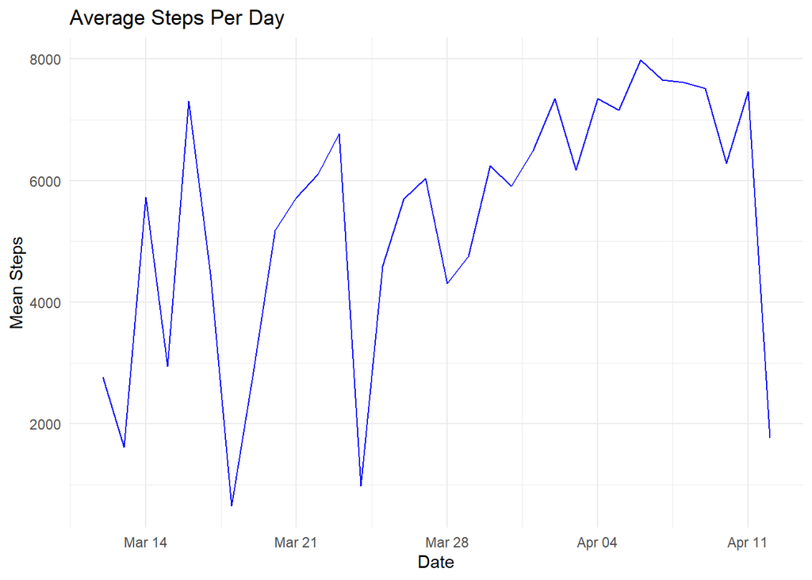

```r
# Line plot for daily total steps
ggplot(daily_activity_summary, aes(x = ActivityDate, y = mean_steps)) +
  geom_line(color = "blue") +
  labs(title = "Average Steps Per Day", x = "Date", y = "Mean Steps") +
  theme_minimal()
```

# User Segmentation by Activity Levels

We categorize users into “Sedentary,” “Moderately Active,” and “Highly Active” based on their total steps.

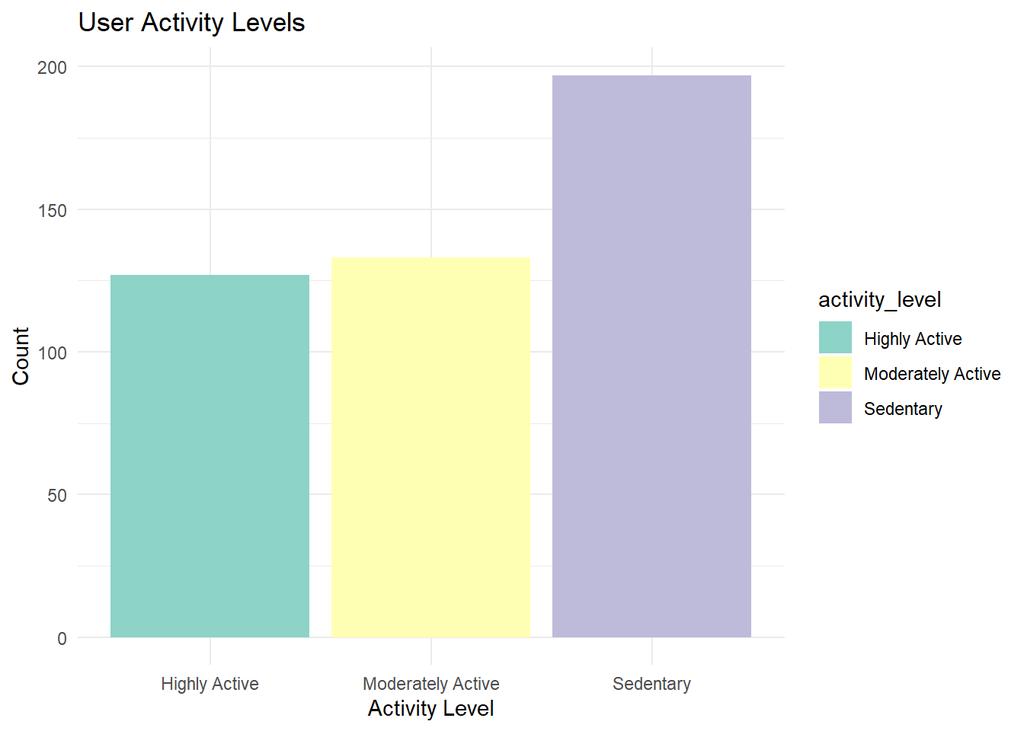

```r
# Categorize users based on TotalSteps
clean_archive <- clean_archive %>%
  mutate(activity_level = case_when(
    TotalSteps < 5000 ~ "Sedentary",
    TotalSteps >= 5000 & TotalSteps < 10000 ~ "Moderately Active",
    TotalSteps >= 10000 ~ "Highly Active"
  ))

# Bar plot for activity levels
ggplot(clean_archive, aes(x = activity_level, fill = activity_level)) +
  geom_bar() +
  labs(title = "User Activity Levels", x = "Activity Level", y = "Count") +
  scale_fill_brewer(palette = "Set3") +
  theme_minimal()
```

# Correlation Between Steps and Calories Burned

We examine the relationship between the number of steps taken and the calories burned using a scatter plot.

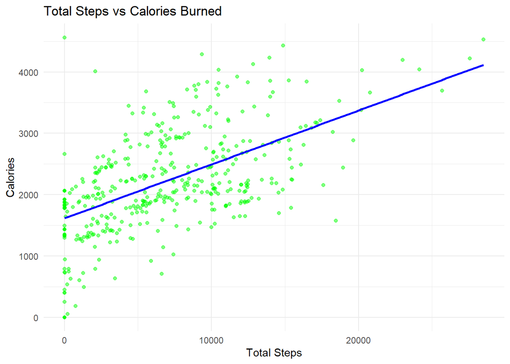

```r
# Scatter plot of TotalSteps vs Calories burned with regression line
ggplot(clean_archive, aes(x = TotalSteps, y = Calories)) +
  geom_point(alpha = 0.5, color = "green") +
  geom_smooth(method = "lm", color = "blue", se = FALSE) +
  labs(title = "Total Steps vs Calories Burned", x = "Total Steps", y = "Calories") +
  theme_minimal()
```

# Average Steps and Calories by Week

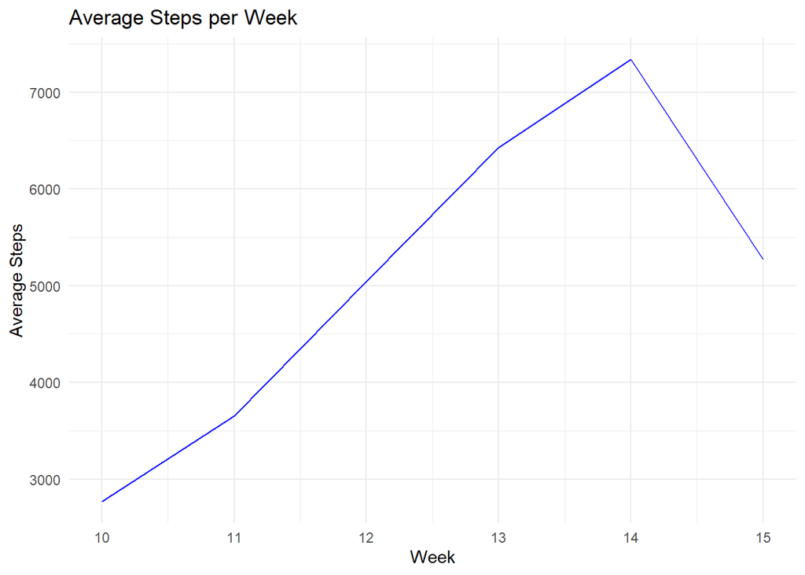

```r
# Convert ActivityDate to week number
clean_archive <- clean_archive %>%
  mutate(week = as.integer(format(ActivityDate, "%U")))

# Summarize mean steps and calories per week
weekly_summary <- clean_archive %>%
  group_by(week) %>%
  summarise(mean_steps = mean(TotalSteps, na.rm = TRUE),
            mean_calories = mean(Calories, na.rm = TRUE))

# Plot average steps per week
ggplot(weekly_summary, aes(x = week, y = mean_steps)) +
  geom_line(color = "blue") +
  labs(title = "Average Steps per Week", x = "Week", y = "Average Steps") +
  theme_minimal()
```

# Calories Burned by Activity Level

We analyze how calories burned vary across different activity levels.

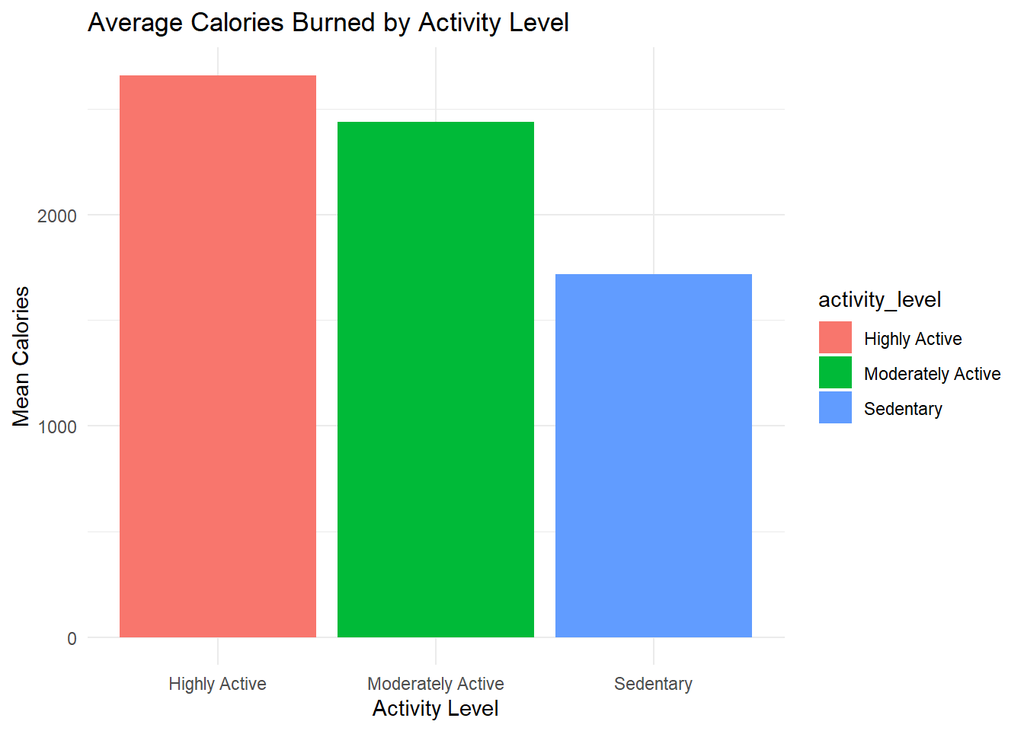

```r
# Bar plot to compare average calories burned by activity level
activity_summary <- clean_archive %>%
  group_by(activity_level) %>%
  summarise(mean_calories = mean(Calories, na.rm = TRUE))

ggplot(activity_summary, aes(x = activity_level, y = mean_calories, fill = activity_level)) +
  geom_bar(stat = "identity") +
  labs(title = "Average Calories Burned by Activity Level", x = "Activity Level", y = "Mean Calories") +
  theme_minimal()
```

# Correlation Between Steps and Calories Burned

We examine the relationship between steps taken and calories burned using a scatter plot.

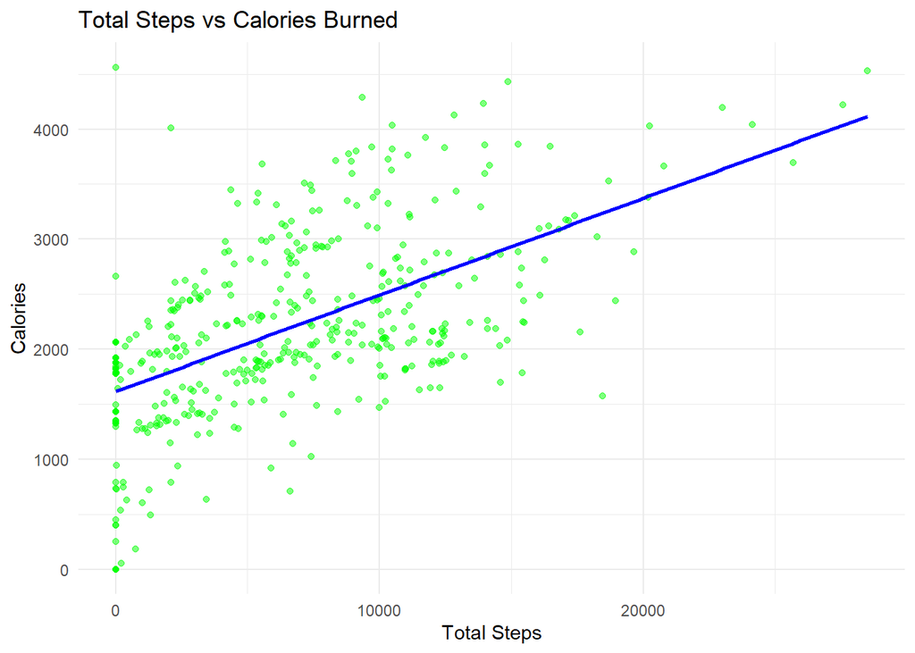

```r
# Scatter plot of TotalSteps vs Calories burned with regression line
ggplot(clean_archive, aes(x = TotalSteps, y = Calories)) +
  geom_point(alpha = 0.5, color = "green") +
  geom_smooth(method = "lm", color = "blue", se = FALSE) +
  labs(title = "Total Steps vs Calories Burned", x = "Total Steps", y = "Calories") +
  theme_minimal()
```

# Key Findings:

**Daily Activity Fluctuations** – There are noticeable fluctuations in daily step counts, with some days showing significantly lower activity compared to others, indicating potential engagement gaps.

# Recommendations:

**Target Sedentary Users with Engagement Campaigns** – Since sedentary users make up a significant portion of the user base, Bellabeat could introduce personalized challenges, in-app reminders, or motivational messages to encourage daily step goals and increase overall activity levels.

**Introduce Incentives for Moderately Active Users** – To keep the moderately active segment engaged, consider offering rewards, badges, or even health insights for achieving consistent step milestones, motivating users to transition into the highly active category.

**Premium Features for Highly Active Users** – Bellabeat could develop exclusive content or premium features for highly active users, such as advanced fitness insights, workout recommendations, or early access to new app features. This would enhance user retention for this highly engaged group.

**Leverage Data-Driven Insights to Launch Time-Sensitive Campaigns** – Based on weekly activity trends, there may be specific weeks or periods where user engagement drops. Bellabeat could time promotional campaigns, fitness events, or community challenges during these lower activity periods to keep engagement consistent year-round.

**Highlight the Calories Burned Benefit** – The clear correlation between steps and calories burned can be used as a marketing point. Users could receive personalized summaries or notifications showing how their activity directly contributes to their health, reinforcing the benefit of staying active.

### 7. References

The analysis and code used here can be found on:

- [Datascienceportfolio: Project Repository](https://www.kaggle.com/code/edgarcontreras2321/notebookae74010603/edit)

Resources and guidelines for Google Data Analytics:

- [Case Study Guidelines](https://github.com/v-Vahe/FItnessTracker_Case_Study/blob/main/Case-Study-Guidelines.pdf)

For data privacy information:

- [Fitness Tracker Data Privacy](https://openeffect.ca/fitness-trackers/Fitness_Tracker_Questions.pdf)
- [Bellabeat’s Privacy Policy](https://bellabeat.com/privacy-policy/)

Data source:

- [Kaggle Dataset Link](https://www.kaggle.com/arashnic/fitbit)